# European Soccer Database Investigation Project

- Introduction
- Data Wrangling
- Exploratory Data Analysis
- Conclusions

## Introduction

This database contains +25,000 european Soccer (Football) matches along with +10,000 players' data and their attirbutes. It covers seasons from 2008 to 2016 in 11 european countries including each team of the lead leauge and the teams' attributes. The whole database are provided through Kaggle datasets as a stort of a databse file containing different linked tables. More information is provided through the [database link](https://www.kaggle.com/mkg2020/exploring-the-european-soccer-database/notebook).

There are tons of questions that can be answered during the investiagtion of this database but the focus will be on three dependent variables: Match result, Player performance, and Team performance. In addition, some comparisons between countries can be presented. The detailed questions are asked after reading the database and getting its general properties.

**Note: Please don't change any cell unless otherwise noted.**

```python
# import requried libraries
import numpy as np
import pandas as pd
import sqlite3
import matplotlib.pyplot as plt
%matplotlib inline
import seaborn as sns
sns.set_style('darkgrid')
import warnings
warnings.simplefilter(action='ignore', category=np.VisibleDeprecationWarning)
```

## Data Wrangling

There are 7 tables to load and get a summary about it. The following two functions where the first one loads one table and returns it as a datafram, and the other one give a summary about the loaded dataframe.

### General Properties

```python
def read_data(table_name):
    '''
    Argument: table_name as a string
    Usage: loads all the columns of this table from the database into a dataframe
    Output: dataframe
    '''
    con = sqlite3.connect("database.sqlite")
    df = pd.read_sql_query("SELECT * from {}".format(table_name), con)
    return df
    con.close()
```

```python
def df_summary(df):
    '''
    Argument: df as a dataframe
    Usage: gives a summary about the dataframe (Number of rows and columns, datatypes, descriptive statistics,
    check for duplication, and display some rows)
    Output: No return
    '''
    # display all columns
    pd.set_option('display.max_columns', None)

    print('Number of rows = {}\nNumber of columns = {}'.format(df.shape[0], df.shape[1]))
    print('-'*30)
    print('Columns info:')
    print(df.info())
    print('-'*30)
    print('Check for duplicates:')
    print(df.duplicated().value_counts())
    print('-'*30)
    print('Summary statistics:')
    print(df.describe())
    print('-'*30)
    print('First five rows:')
    print(df.head())
    print('-'*30)
    print('Last five rows:')
    print(df.tail())
    print('-'*30)
```

#### 1. Country

```python
df_country = read_data('Country')
df_summary(df_country)
```

```
Number of rows = 11
Number of columns = 2
------------------------------
Columns info:
<class 'pandas.core.frame.DataFrame'>
RangeIndex: 11 entries, 0 to 10
Data columns (total 2 columns):
 #   Column  Non-Null Count  Dtype
---  ------  --------------  -----
 0   id      11 non-null     int64
 1   name    11 non-null     object
dtypes: int64(1), object(1)
memory usage: 304.0+ bytes
None
------------------------------
Check for duplicates:
False    11
dtype: int64
------------------------------
Summary statistics:
                 id
count     11.000000
mean   12452.090909
std     8215.308472
min        1.000000
25%     6289.000000
50%    13274.000000
75%    18668.000000
max    24558.000000
------------------------------
First five rows:
      id     name
0      1  Belgium
1   1729  England
2   4769   France
3   7809  Germany
4  10257    Italy
------------------------------
Last five rows:
       id         name
6   15722       Poland
7   17642     Portugal
8   19694     Scotland
9   21518        Spain
10  24558  Switzerland
------------------------------
```

The Country tables contains 11 countries names and their IDs **with no duplicates and no null values**.

Finally, the datatypes seem to be correct here.

#### 2. League

```python
df_league = read_data('League')
df_summary(df_league)
```

```
Number of rows = 11
Number of columns = 3
------------------------------
Columns info:
<class 'pandas.core.frame.DataFrame'>
RangeIndex: 11 entries, 0 to 10
Data columns (total 3 columns):
 #   Column      Non-Null Count  Dtype
---  ------      --------------  -----
 0   id          11 non-null     int64
 1   country_id  11 non-null     int64
 2   name        11 non-null     object
dtypes: int64(2), object(1)
memory usage: 392.0+ bytes
None
------------------------------
Check for duplicates:
False    11
dtype: int64
------------------------------
Summary statistics:
                 id    country_id
count     11.000000     11.000000
mean   12452.090909  12452.090909
std     8215.308472   8215.308472
min        1.000000      1.000000
25%     6289.000000   6289.000000
50%    13274.000000  13274.000000
75%    18668.000000  18668.000000
max    24558.000000  24558.000000
------------------------------
First five rows:
      id  country_id                    name
0      1           1  Belgium Jupiler League
1   1729        1729  England Premier League
2   4769        4769          France Ligue 1
3   7809        7809   Germany 1. Bundesliga
4  10257       10257           Italy Serie A
------------------------------
Last five rows:
       id  country_id                      name
6   15722       15722        Poland Ekstraklasa
7   17642       17642  Portugal Liga ZON Sagres
8   19694       19694   Scotland Premier League
9   21518       21518           Spain LIGA BBVA
10  24558       24558  Switzerland Super League
------------------------------
```

The League table cotains 3 columns with an ID of each row where each leauge name is associated to the country_id which can be linked to the Country table to get the country name. **This table has no duplicates and no null values**.

Finally, the datatypes seem to be correct here.

#### 3. Match

```python
df_match = read_data('Match')
df_summary(df_match)
```

```
Number of rows = 25979
Number of columns = 115
------------------------------
Columns info:
<class 'pandas.core.frame.DataFrame'>
RangeIndex: 25979 entries, 0 to 25978
Columns: 115 entries, id to BSA
dtypes: float64(96), int64(9), object(10)
memory usage: 22.8+ MB
None
------------------------------
Check for duplicates:
False    25979
dtype: int64
------------------------------
Summary statistics:
                 id    country_id     league_id         stage  match_api_id  \
count  25979.000000  25979.000000  25979.000000  25979.000000  2.597900e+04
mean   12990.000000  11738.630317  11738.630317     18.242773  1.195429e+06
std     7499.635658   7553.936759   7553.936759     10.407354  4.946279e+05
min        1.000000      1.000000      1.000000      1.000000  4.831290e+05
25%     6495.500000   4769.000000   4769.000000      9.000000  7.684365e+05
50%    12990.000000  10257.000000  10257.000000     18.000000  1.147511e+06
75%    19484.500000  17642.000000  17642.000000     27.000000  1.709852e+06
max    25979.000000  24558.000000  24558.000000     38.000000  2.216672e+06

       home_team_api_id  away_team_api_id  home_team_goal  away_team_goal  \
count      25979.000000      25979.000000    25979.000000    25979.000000
mean        9984.371993       9984.475115        1.544594        1.160938
std        14087.453758      14087.445135        1.297158        1.142110
min         1601.000000       1601.000000        0.000000        0.000000
25%         8475.000000       8475.000000        1.000000        0.000000
50%         8697.000000       8697.000000        1.000000        1.000000
75%         9925.000000       9925.000000        2.000000        2.000000
max       274581.000000     274581.000000       10.000000        9.000000

       home_player_X1  home_player_X2  home_player_X3  home_player_X4  \
count    24158.000000    24158.000000    24147.000000    24147.000000
mean         0.999586        2.073516        4.061001        6.049199
std          0.022284        0.387185        0.385973        0.446024
```

[output cut: 521 more lines]

```

       BWA  IWH  IWD  IWA  LBH  LBD  LBA  PSH  PSD  PSA  WHH  WHD  WHA  SJH  \
25974  NaN  NaN  NaN  NaN  NaN  NaN  NaN  NaN  NaN  NaN  NaN  NaN  NaN  NaN
25975  NaN  NaN  NaN  NaN  NaN  NaN  NaN  NaN  NaN  NaN  NaN  NaN  NaN  NaN
25976  NaN  NaN  NaN  NaN  NaN  NaN  NaN  NaN  NaN  NaN  NaN  NaN  NaN  NaN
25977  NaN  NaN  NaN  NaN  NaN  NaN  NaN  NaN  NaN  NaN  NaN  NaN  NaN  NaN
25978  NaN  NaN  NaN  NaN  NaN  NaN  NaN  NaN  NaN  NaN  NaN  NaN  NaN  NaN

       SJD  SJA  VCH  VCD  VCA  GBH  GBD  GBA  BSH  BSD  BSA
25974  NaN  NaN  NaN  NaN  NaN  NaN  NaN  NaN  NaN  NaN  NaN
25975  NaN  NaN  NaN  NaN  NaN  NaN  NaN  NaN  NaN  NaN  NaN
25976  NaN  NaN  NaN  NaN  NaN  NaN  NaN  NaN  NaN  NaN  NaN
25977  NaN  NaN  NaN  NaN  NaN  NaN  NaN  NaN  NaN  NaN  NaN
25978  NaN  NaN  NaN  NaN  NaN  NaN  NaN  NaN  NaN  NaN  NaN
------------------------------
```

The Match table contains 25979 **distinct** matches with an id of each match. The other 114 columns are as follows:

- IDs to link with other tables (Country, Leauge, Match API ID, Home Team API ID, Away Team API) **with no null values**
- Match info (Season, Stage, Date) **with no null values**
- Number of goals scored by the home team and the away team **with no null values**
- Home and away players' positions in the lineup from X1 to X11 and from Y1 to Y11 **with small null values**
- Home and away lineup players' IDs from 1 to 11 to be linked with the players' tables **with small null values**
- Match facts (goals, shots, fouls, cards, crosses, corners, possession) **with huge null values**
- The remaining values are related to betting odds of up to 10 providers **with varying null values**

By looking into summary statistics, the numerical values are reasonable.

Finally, the datatypes seem to be correct but they need more investigation for the three attributes with string values. more investigation for the match facts as they should be either integers or distict string values that can be groubed. The Season column will be checked also.

```python
print(df_match[df_match['goal'].isnull()==False][['goal', 'shoton', 'shotoff', 'foulcommit', 'card', 'cross', 'corner', 'possession']].head())
print('-'*30)
print(df_match['season'].value_counts())
```

```
                                                   goal  \
1728  <goal><value><comment>n</comment><stats><goals...
1729  <goal><value><comment>n</comment><stats><goals...
1730  <goal><value><comment>n</comment><stats><goals...
1731  <goal><value><comment>n</comment><stats><goals...
1732  <goal><value><comment>n</comment><stats><goals...

                                                 shoton  \
1728  <shoton><value><stats><blocked>1</blocked></st...
1729  <shoton><value><stats><blocked>1</blocked></st...
1730  <shoton><value><stats><blocked>1</blocked></st...
1731  <shoton><value><stats><shoton>1</shoton></stat...
1732  <shoton><value><stats><blocked>1</blocked></st...

                                                shotoff  \
1728  <shotoff><value><stats><shotoff>1</shotoff></s...
1729  <shotoff><value><stats><shotoff>1</shotoff></s...
1730  <shotoff><value><stats><shotoff>1</shotoff></s...
1731  <shotoff><value><stats><shotoff>1</shotoff></s...
1732  <shotoff><value><stats><shotoff>1</shotoff></s...

                                             foulcommit  \
1728  <foulcommit><value><stats><foulscommitted>1</f...
1729  <foulcommit><value><stats><foulscommitted>1</f...
1730  <foulcommit><value><stats><foulscommitted>1</f...
1731  <foulcommit><value><stats><foulscommitted>1</f...
1732  <foulcommit><value><stats><foulscommitted>1</f...

                                                   card  \
1728  <card><value><comment>y</comment><stats><ycard...
1729                                           <card />
1730  <card><value><comment>y</comment><stats><ycard...
1731  <card><value><comment>y</comment><stats><ycard...
1732  <card><value><comment>y</comment><stats><ycard...

                                                  cross  \
1728  <cross><value><stats><crosses>1</crosses></sta...
1729  <cross><value><stats><crosses>1</crosses></sta...
1730  <cross><value><stats><crosses>1</crosses></sta...
1731  <cross><value><stats><crosses>1</crosses></sta...
```

[output cut: 10 more lines]

```
1728  <possession><value><comment>56</comment><event...
1729  <possession><value><comment>65</comment><event...
1730  <possession><value><comment>45</comment><event...
1731  <possession><value><comment>50</comment><event...
1732  <possession><value><comment>51</comment><event...
------------------------------
2015/2016    3326
2008/2009    3326
2014/2015    3325
2010/2011    3260
2012/2013    3260
2009/2010    3230
2011/2012    3220
2013/2014    3032
Name: season, dtype: int64
```

As expected, the match facts columns' have wrong entries. It seems that there was a problem during the web scraping process. But the season column is entered correctly.

#### 4. Player

```python
df_player = read_data('Player')
df_summary(df_player)
```

```
Number of rows = 11060
Number of columns = 7
------------------------------
Columns info:
<class 'pandas.core.frame.DataFrame'>
RangeIndex: 11060 entries, 0 to 11059
Data columns (total 7 columns):
 #   Column              Non-Null Count  Dtype
---  ------              --------------  -----
 0   id                  11060 non-null  int64
 1   player_api_id       11060 non-null  int64
 2   player_name         11060 non-null  object
 3   player_fifa_api_id  11060 non-null  int64
 4   birthday            11060 non-null  object
 5   height              11060 non-null  float64
 6   weight              11060 non-null  int64
dtypes: float64(1), int64(4), object(2)
memory usage: 605.0+ KB
None
------------------------------
Check for duplicates:
False    11060
dtype: int64
------------------------------
Summary statistics:
                 id  player_api_id  player_fifa_api_id        height  \
count  11060.000000   11060.000000        11060.000000  11060.000000
mean    5537.511392  156582.427215       165664.910488    181.867445
std     3197.692647  160713.700624        58649.928360      6.369201
min        1.000000    2625.000000            2.000000    157.480000
25%     2767.750000   35555.500000       151889.500000    177.800000
50%     5536.500000   96619.500000       184671.000000    182.880000
75%     8306.250000  212470.500000       203883.250000    185.420000
max    11075.000000  750584.000000       234141.000000    208.280000

             weight
count  11060.000000
mean     168.380289
std       14.990217
min      117.000000
```

[output cut: 20 more lines]

```
Last five rows:
          id  player_api_id          player_name  player_fifa_api_id  \
11055  11071          26357       Zoumana Camara                2488
11056  11072         111182         Zsolt Laczko              164680
11057  11073          36491            Zsolt Low              111191
11058  11074          35506  Zurab Khizanishvili               47058
11059  11075          39902   Zvjezdan Misimovic              102359

                  birthday  height  weight
11055  1979-04-03 00:00:00  182.88     168
11056  1986-12-18 00:00:00  182.88     176
11057  1979-04-29 00:00:00  180.34     154
11058  1981-10-06 00:00:00  185.42     172
11059  1982-06-05 00:00:00  180.34     176
------------------------------
```

The Player table contains 11060 **distinct palyer** with an ID of each row. Each player is associated to two different IDs (API ID and FIFA API ID). There are 4 other columns that give the player name, birthday, height, and weight. **This table has no null values**.

By looking into summary statistics, the numerical values are reasonable.

Finally, the datatypes seem to be correct here with heights in cms and weights in pounds.

#### 5. Player_Attributes

```python
df_player_attributes = read_data('Player_Attributes')
df_summary(df_player_attributes)
```

```
Number of rows = 183978
Number of columns = 42
------------------------------
Columns info:
<class 'pandas.core.frame.DataFrame'>
RangeIndex: 183978 entries, 0 to 183977
Data columns (total 42 columns):
 #   Column               Non-Null Count   Dtype
---  ------               --------------   -----
 0   id                   183978 non-null  int64
 1   player_fifa_api_id   183978 non-null  int64
 2   player_api_id        183978 non-null  int64
 3   date                 183978 non-null  object
 4   overall_rating       183142 non-null  float64
 5   potential            183142 non-null  float64
 6   preferred_foot       183142 non-null  object
 7   attacking_work_rate  180748 non-null  object
 8   defensive_work_rate  183142 non-null  object
 9   crossing             183142 non-null  float64
 10  finishing            183142 non-null  float64
 11  heading_accuracy     183142 non-null  float64
 12  short_passing        183142 non-null  float64
 13  volleys              181265 non-null  float64
 14  dribbling            183142 non-null  float64
 15  curve                181265 non-null  float64
 16  free_kick_accuracy   183142 non-null  float64
 17  long_passing         183142 non-null  float64
 18  ball_control         183142 non-null  float64
 19  acceleration         183142 non-null  float64
 20  sprint_speed         183142 non-null  float64
 21  agility              181265 non-null  float64
 22  reactions            183142 non-null  float64
 23  balance              181265 non-null  float64
 24  shot_power           183142 non-null  float64
 25  jumping              181265 non-null  float64
 26  stamina              183142 non-null  float64
 27  strength             183142 non-null  float64
 28  long_shots           183142 non-null  float64
 29  aggression           183142 non-null  float64
 30  interceptions        183142 non-null  float64
```

[output cut: 226 more lines]

```

        marking  standing_tackle  sliding_tackle  gk_diving  gk_handling  \
183973     22.0             31.0            30.0        9.0         20.0
183974     32.0             31.0            30.0        9.0         20.0
183975     32.0             31.0            30.0        9.0         20.0
183976     28.0             32.0            30.0        9.0         20.0
183977     38.0             32.0            30.0        9.0          9.0

        gk_kicking  gk_positioning  gk_reflexes
183973        84.0            20.0         20.0
183974        73.0            20.0         20.0
183975        73.0            20.0         20.0
183976        73.0            20.0         20.0
183977        78.0             7.0         15.0
------------------------------
```

The player attributes table continas 183978 **distinct** rows of player attributes like overall rating, preferred_foot, crossing skills score, penalities siklls score, and much more. There are 38 different attributes which are explained through [FIFA play encyclopedia](https://www.fifplay.com/encyclopedia/player-attributes/) **with small null values**. The remaining columns are IDs (Row ID, player FIFA API ID, player API ID) which can be used to link with other tables. Each distict player can have more than one row of his attributes on diffrent dates which is indicated in the date column.

By looking into summary statistics, the numerical values are reasonable.

The datatypes seem to be correct here but they need more investigation for the three attributes with string values.

```python
print(df_player_attributes['preferred_foot'].value_counts())
print('-'*30)
print(df_player_attributes['attacking_work_rate'].value_counts())
print('-'*30)
print(df_player_attributes['defensive_work_rate'].value_counts())
```

```
right    138409
left      44733
Name: preferred_foot, dtype: int64
------------------------------
medium    125070
high       42823
low         8569
None        3639
norm         348
y            106
le           104
stoc          89
Name: attacking_work_rate, dtype: int64
------------------------------
medium    130846
high       27041
low        18432
_0          2394
o           1550
1            441
ormal        348
2            342
3            258
5            234
7            217
6            197
0            197
9            152
4            116
es           106
ean          104
tocky         89
8             78
Name: defensive_work_rate, dtype: int64
```

The preferref foot column is entered correctly, but the attacking and defensive work rate columns have wrong enteries. So, we have two options here, to drop these two columns or drop the rows with wrong enteries.

Then, we can investigate how frequent these attributes are updated by looking at the values of the date column.

```python
print(df_player_attributes.groupby(['player_api_id', 'date']).sum()['overall_rating'])
```

```
player_api_id  date
2625           2007-02-22 00:00:00    63.0
               2007-08-30 00:00:00    63.0
               2008-08-30 00:00:00    60.0
               2010-08-30 00:00:00    60.0
               2011-02-22 00:00:00    59.0
                                      ...
750435         2016-02-04 00:00:00    56.0
               2016-02-11 00:00:00    56.0
               2016-04-14 00:00:00    60.0
750584         2007-02-22 00:00:00    58.0
               2016-05-19 00:00:00    58.0
Name: overall_rating, Length: 183142, dtype: float64
```

The frequency of updating the players' attributes varies from one player to another, some players have +10 updates and other have only two.

#### 6. Team

```python
df_team = read_data('Team')
df_summary(df_team)
```

```
Number of rows = 299
Number of columns = 5
------------------------------
Columns info:
<class 'pandas.core.frame.DataFrame'>
RangeIndex: 299 entries, 0 to 298
Data columns (total 5 columns):
 #   Column            Non-Null Count  Dtype
---  ------            --------------  -----
 0   id                299 non-null    int64
 1   team_api_id       299 non-null    int64
 2   team_fifa_api_id  288 non-null    float64
 3   team_long_name    299 non-null    object
 4   team_short_name   299 non-null    object
dtypes: float64(1), int64(2), object(2)
memory usage: 11.8+ KB
None
------------------------------
Check for duplicates:
False    299
dtype: int64
------------------------------
Summary statistics:
                 id    team_api_id  team_fifa_api_id
count    299.000000     299.000000        288.000000
mean   23735.301003   12340.521739      21534.305556
std    15167.914719   25940.411135      42456.439408
min        1.000000    1601.000000          1.000000
25%     9552.500000    8349.000000        178.750000
50%    22805.000000    8655.000000        673.500000
75%    36250.500000    9886.500000       1910.750000
max    51606.000000  274581.000000     112513.000000
------------------------------
First five rows:
   id  team_api_id  team_fifa_api_id     team_long_name team_short_name
0   1         9987             673.0           KRC Genk             GEN
1   2         9993             675.0       Beerschot AC             BAC
2   3        10000           15005.0   SV Zulte-Waregem             ZUL
3   4         9994            2007.0   Sporting Lokeren             LOK
4   5         9984            1750.0  KSV Cercle Brugge             CEB
------------------------------
Last five rows:
        id  team_api_id  team_fifa_api_id      team_long_name team_short_name
294  49479        10190             898.0       FC St. Gallen             GAL
295  49837        10191            1715.0             FC Thun             THU
296  50201         9777             324.0         Servette FC             SER
297  50204         7730            1862.0  FC Lausanne-Sports             LAU
298  51606         7896               NaN              Lugano             LUG
------------------------------
```

The Team table gives the data about 299 **distinct** teams with different IDs for each team. The other two columns give the team's short and long names. **The table continas only 11 null values in the column "team_fifa_api_id"**.

Finally, the datatypes seem to be correct here.

#### 7. Team_Attributes

```python
df_team_attributes = read_data('Team_Attributes')
df_summary(df_team_attributes)
```

```
Number of rows = 1458
Number of columns = 25
------------------------------
Columns info:
<class 'pandas.core.frame.DataFrame'>
RangeIndex: 1458 entries, 0 to 1457
Data columns (total 25 columns):
 #   Column                          Non-Null Count  Dtype
---  ------                          --------------  -----
 0   id                              1458 non-null   int64
 1   team_fifa_api_id                1458 non-null   int64
 2   team_api_id                     1458 non-null   int64
 3   date                            1458 non-null   object
 4   buildUpPlaySpeed                1458 non-null   int64
 5   buildUpPlaySpeedClass           1458 non-null   object
 6   buildUpPlayDribbling            489 non-null    float64
 7   buildUpPlayDribblingClass       1458 non-null   object
 8   buildUpPlayPassing              1458 non-null   int64
 9   buildUpPlayPassingClass         1458 non-null   object
 10  buildUpPlayPositioningClass     1458 non-null   object
 11  chanceCreationPassing           1458 non-null   int64
 12  chanceCreationPassingClass      1458 non-null   object
 13  chanceCreationCrossing          1458 non-null   int64
 14  chanceCreationCrossingClass     1458 non-null   object
 15  chanceCreationShooting          1458 non-null   int64
 16  chanceCreationShootingClass     1458 non-null   object
 17  chanceCreationPositioningClass  1458 non-null   object
 18  defencePressure                 1458 non-null   int64
 19  defencePressureClass            1458 non-null   object
 20  defenceAggression               1458 non-null   int64
 21  defenceAggressionClass          1458 non-null   object
 22  defenceTeamWidth                1458 non-null   int64
 23  defenceTeamWidthClass           1458 non-null   object
 24  defenceDefenderLineClass        1458 non-null   object
dtypes: float64(1), int64(11), object(13)
memory usage: 284.9+ KB
None
------------------------------
Check for duplicates:
False    1458
```

[output cut: 156 more lines]

```

     defenceAggressionClass  defenceTeamWidth defenceTeamWidthClass  \
1453                  Press                53                Normal
1454                  Press                53                Normal
1455                  Press                37                Normal
1456                  Press                37                Normal
1457                  Press                37                Normal

     defenceDefenderLineClass
1453                    Cover
1454                    Cover
1455                    Cover
1456                    Cover
1457                    Cover
------------------------------
```

The Team attriubutes table gives 1458 **distinct** rows of teams' attributes like buildup play speed and its class, chance creation passing and its class, defence pressure and its class, the position class and much more. There are 21 different attributes of each team **with null values at only one column**. Each distict team can have more than one row of his attributes on diffrent dates which is indicated in the date column. The remaining columns are IDs (Row ID, team FIFA API ID, team API ID) which can be used to link with other tables.

By looking into the rows with NaN values at the buildup play dribbling column, it seems that it is associated with "Little" value into the buildup play dribbling class which means it is not null value rather it is small value. This small value might be smaller than the min value of the columns which is 24 as indicated from the summary statistics. The following cell checks for that.

By looking into summary statistics, the numerical values are reasonable.

```python
# Let's check if all nan values are associated with Little Class of the buildup play dribbling attribute
print(df_team_attributes[df_team_attributes['buildUpPlayDribbling'].isnull()==True].buildUpPlayDribblingClass.value_counts())
print('-'*30)
# Let's get the limits of each class
print(df_team_attributes.groupby(['buildUpPlayDribblingClass']).min()['buildUpPlayDribbling'])
```

```
Little    969
Name: buildUpPlayDribblingClass, dtype: int64
------------------------------
buildUpPlayDribblingClass
Little    24.0
Lots      67.0
Normal    34.0
Name: buildUpPlayDribbling, dtype: float64
```

It's true that all NaN values of the buildup play dribbling column is assoicated with Little class. And, the min values of the buildup play dribbling class column are 24, 34, and 67 for the "Little", "Normal", and "Lots" classes respectively. Then the NaN values can be corrected by adding a value of 24 or just the average between the class boundaries (24 and 33).

```python
print(df_team_attributes['buildUpPlaySpeedClass'].value_counts())
print('-'*30)
print(df_team_attributes['buildUpPlayDribblingClass'].value_counts())
print('-'*30)
print(df_team_attributes['buildUpPlayPassingClass'].value_counts())
print('-'*30)
print(df_team_attributes['buildUpPlayPositioningClass'].value_counts())
print('-'*30)
print(df_team_attributes['chanceCreationPassingClass'].value_counts())
print('-'*30)
print(df_team_attributes['chanceCreationCrossingClass'].value_counts())
print('-'*30)
print(df_team_attributes['chanceCreationShootingClass'].value_counts())
print('-'*30)
print(df_team_attributes['chanceCreationPositioningClass'].value_counts())
print('-'*30)
print(df_team_attributes['defencePressureClass'].value_counts())
print('-'*30)
print(df_team_attributes['defenceAggressionClass'].value_counts())
print('-'*30)
print(df_team_attributes['defenceTeamWidthClass'].value_counts())
print('-'*30)
print(df_team_attributes['defenceDefenderLineClass'].value_counts())
print('-'*30)
```

```
Balanced    1184
Fast         172
Slow         102
Name: buildUpPlaySpeedClass, dtype: int64
------------------------------
Little    1004
Normal     433
Lots        21
Name: buildUpPlayDribblingClass, dtype: int64
------------------------------
Mixed    1236
Short     128
Long       94
Name: buildUpPlayPassingClass, dtype: int64
------------------------------
Organised    1386
Free Form      72
Name: buildUpPlayPositioningClass, dtype: int64
------------------------------
Normal    1231
Risky      171
Safe        56
Name: chanceCreationPassingClass, dtype: int64
------------------------------
Normal    1195
Lots       211
Little      52
Name: chanceCreationCrossingClass, dtype: int64
------------------------------
Normal    1224
Lots       197
Little      37
Name: chanceCreationShootingClass, dtype: int64
------------------------------
Organised    1309
Free Form     149
Name: chanceCreationPositioningClass, dtype: int64
------------------------------
Medium    1243
Deep       154
High        61
Name: defencePressureClass, dtype: int64
------------------------------
Press      1274
Double       99
Contain      85
Name: defenceAggressionClass, dtype: int64
------------------------------
Normal    1286
Wide       111
Narrow      61
Name: defenceTeamWidthClass, dtype: int64
------------------------------
Cover           1362
Offside Trap      96
Name: defenceDefenderLineClass, dtype: int64
------------------------------
```

All these attributes are entered correctly. Great!

### Possible and Impossible Quesitions

Now, it's possible to ask some questions but there are impossible ones:

The possible questions are:

1. Which league or country has most goals?
2. Which league or country has most Home wins and most Away wins?
3. Which teams have most scored goals for Home and Away matches?
4. Which teams have most golas difference (socred minus conceded) for Home and Away matches?
5. Which teams have most winning percentage for Home and Away matches?
6. What are the factors that might affect the match results?
7. Which players have improved the most?
8. Which teams have improved the most?

The impossible questions are:

- Questions about fouls, cards, corners, ... >>> Because of wrong entries
- Questions about players with most goals, penalities, passes, ... >>> Because of lack of data

### General Data Cleaning

1. Drop columns with wrong entries and the columns of betting odds because they are out of the scope of this analysis.
2. Add the country name and the team name to the matches table.
3. Change date columns to datetime.
4. Drop the rows with nan values from the player attributes table
5. Drop the rows with wrong entries from the player attributes table
6. Fill nan values from the team attributes table with the smallest value

This is the general clening process to help in answering all questions. However, further cleaning is requried to answer some questions.

```python
# 1. Drop columns with wrong entries and the columns of betting odds
start = df_match.columns.get_loc('goal') # get the goal column index
columns = np.arange(start, df_match.shape[1]) # set all columns' indecies to be dropped
df_match.drop(df_match.columns[columns], axis=1, inplace=True)
```

```python
# 2. Add the country name and the team name to the matches table
df_match['country_name'] = df_match['country_id'].map(df_country.set_index('id')['name'])
df_match['home_team_name'] = df_match['home_team_api_id'].map(df_team.set_index('team_api_id')['team_long_name'])
df_match['away_team_name'] = df_match['away_team_api_id'].map(df_team.set_index('team_api_id')['team_long_name'])
```

```python
# 3. Change date columns to datetime
df_match['date'] = pd.to_datetime(df_match['date'])
df_player['birthday'] = pd.to_datetime(df_player['birthday'])
df_player_attributes['date'] = pd.to_datetime(df_player_attributes['date'])
df_team_attributes['date'] = pd.to_datetime(df_team_attributes['date'])
```

```python
# 4. Drop the rows with nan values from the player attributes table
df_player_attributes.dropna(inplace=True)
```

```python
# 5. Drop the rows with wrong entries from the player attributes table
correct_entries = ['low', 'medium', 'high']
df_player_attributes = df_player_attributes[df_player_attributes['attacking_work_rate'].isin(correct_entries)]
df_player_attributes = df_player_attributes[df_player_attributes['defensive_work_rate'].isin(correct_entries)]
```

```python
# 6. Fill nan values from the team attributes table with the smallest value
df_team_attributes.fillna(24, inplace=True)
```

## Exploratory Data Analysis

### 1. Which league or country has most goals?

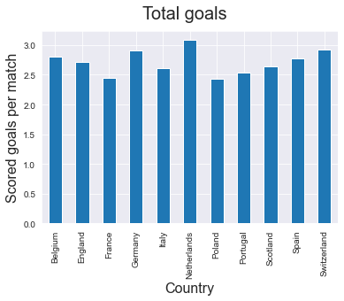

```python
# Get total goals scored on match by adding home and away goals
df_match['total_goals'] = df_match['home_team_goal'] + df_match['away_team_goal']
df_match.groupby(['country_name']).mean()['total_goals'].plot(kind='bar')
plt.suptitle('Total goals', fontsize=20)
plt.xlabel('Country', fontsize=16)
plt.ylabel('Scored goals per match', fontsize=16);
```

**Netherlands** got the league with most scored goals followed by Germany and Switzerland.

### 2. Which league or country has most Home wins, most Away wins, and most Draws?

```python
# Add column to specify the match result (Home win, Away Win, Draw)
df_match['match_result'] = np.where(df_match['home_team_goal']>df_match['away_team_goal'], 'home_win',
                                    np.where(df_match['home_team_goal']<df_match['away_team_goal'], 'away_win', 'draw'))
```

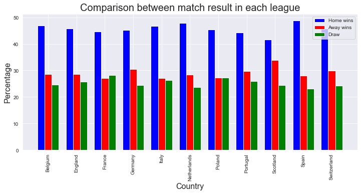

```python
# Determine graph parameters of Home wins
width = 0.25
plt.figure(figsize=(12,5))
heights_home = (df_match.groupby(['match_result']).get_group('home_win').groupby(['country_name']).count()['id']/
                df_match.groupby(['country_name']).count()['id']*100)
locations_home = np.arange(1, len(heights_home)+1)
home_win = plt.bar(locations_home, heights_home, width, color='b', label='Home wins')
# Determine graph parameters of Away wins
heights_away = (df_match.groupby(['match_result']).get_group('away_win').groupby(['country_name']).count()['id']/
                df_match.groupby(['country_name']).count()['id']*100)
locations_away = locations_home + width
away_win = plt.bar(locations_away, heights_away, width, color='r', label='Away wins')
# Determine graph parameters of Draws
heights_draw = (df_match.groupby(['match_result']).get_group('draw').groupby(['country_name']).count()['id']/
                df_match.groupby(['country_name']).count()['id']*100)
locations_draw = locations_home + width*2
away_win = plt.bar(locations_draw, heights_draw, width, color='g', label='Draw')
# Determine general graph parameters
locations = locations_home + width
labels = df_match.groupby(['country_name']).count().index
plt.xticks(locations, labels, rotation=90)
plt.title('Comparison between match result in each league', fontsize=20)
plt.xlabel('Country', fontsize=16)
plt.ylabel('Percentage', fontsize=16)
plt.legend(loc='best');
```

All countries have greater home winning percentage over the other countries followed by away winning in most countries. France is the only country with draw percentage greater than away winning perecentage while Poland has equal percentage between away winning and draw percentages, Those two countries are the leading ones in draw percentages.

**Spain** is the leading country in home winning percentage followed by Netherlands, while **Scoltland** is the leading country in away winning percentage followed by Germany.

It seems that the "home or away" factor affects the match result alot, so home matches and away matches are analyzed separately during the rest of the report.

### 3. Which teams have most scored goals?

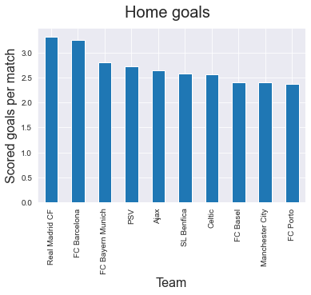

```python
df_match.groupby(['home_team_name']).mean()['home_team_goal'].nlargest(10).plot(kind='bar')
plt.suptitle('Home goals', fontsize=20)
plt.xlabel('Team', fontsize=16)
plt.ylabel('Scored goals per match', fontsize=16);
```

**Real Madrid CF** and **FC Barcelona** are the leading teams in most home goals with a considerable difference between them and the other 8 leading teams.

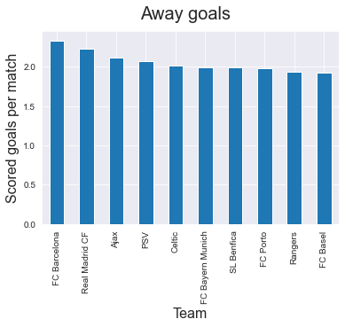

```python
df_match.groupby(['away_team_name']).mean()['away_team_goal'].nlargest(10).plot(kind='bar')
plt.suptitle('Away goals', fontsize=20)
plt.xlabel('Team', fontsize=16)
plt.ylabel('Scored goals per match', fontsize=16);
```

Again, **FC Barcelona** and **Real Madrid CF** are the leading clubs with most away goals.

### 4. Which teams have most golas difference?

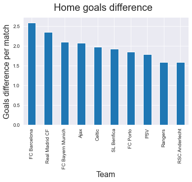

```python
# Calculate the difference between scored goal and conceded goals for home matches
df_match['goals_difference'] = df_match['home_team_goal'] - df_match['away_team_goal']
df_match.groupby(['home_team_name']).mean()['goals_difference'].nlargest(10).plot(kind='bar')
plt.suptitle('Home goals difference', fontsize=20)
plt.xlabel('Team', fontsize=16)
plt.ylabel('Goals difference per match', fontsize=16);
```

Golas' difference is the balance between scoring and recieving goals. Here, **FC Barcelona** got a lead in home goals difference with a considerable gap between it and the following team "Real Madrid CF". Both of them are somewhat far from the other 8 leading teams. Remember that Real Madrid CF was the leading team in scoring in home matches but it recieves more goals than FC Barcelona so, FC Barcelona got the lead. Interseting!

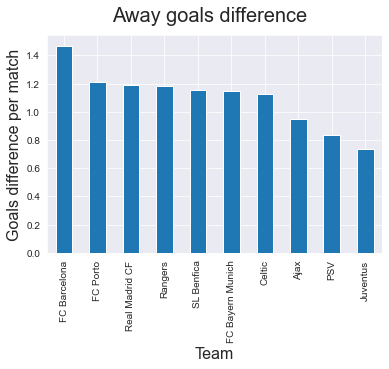

```python
# Switch the sign to get the correct difference for away team
(-df_match.groupby(['away_team_name']).mean()['goals_difference']).nlargest(10).plot(kind='bar')
plt.suptitle('Away goals difference', fontsize=20)
plt.xlabel('Team', fontsize=16)
plt.ylabel('Goals difference per match', fontsize=16);
```

As previous, **FC Barcelona** got the lead in away goals difference with a great gap between the other 9 leading teams!

### 5. Which teams have most winning percentage?

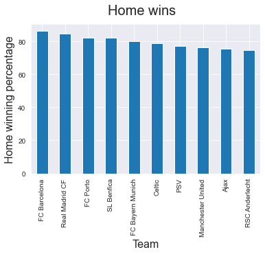

```python
(df_match.groupby(['match_result']).get_group('home_win').groupby(['home_team_name']).count()['id']/
 df_match.groupby(['home_team_name']).count()['id']*100).nlargest(10).plot(kind='bar')
plt.suptitle('Home wins', fontsize=20)
plt.xlabel('Team', fontsize=16)
plt.ylabel('Home winning percentage', fontsize=16);
```

No doubt, **FC Barcelona** and **Real Madrid CF** got the lead in home winning percentages because they are Spanish clubs. Remeber that Spain is the leading country in home winning percentage.

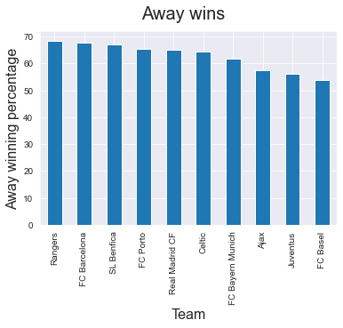

```python
(df_match.groupby(['match_result']).get_group('away_win').groupby(['away_team_name']).count()['id']/
 df_match.groupby(['away_team_name']).count()['id']*100).nlargest(10).plot(kind='bar')
plt.suptitle('Away wins', fontsize=20)
plt.xlabel('Team', fontsize=16)
plt.ylabel('Away winning percentage', fontsize=16);
```

Finally, **Rangers** is the only non-spanish leading team which is leader in away winning percentage. This agrees with the fact that Scotland is the leading country in that.

### 6. What are the factors that might affect the match results?

There are many factors to look at:

- If the team is home or away (It is obvious from the result of the first question, but let's make it clear for the whole countries combined)
- Team lineup player's positions in X and Y directions
- Average players' age
- Players' attributes
- Teams' attributes **Note: These factors will be analyzed one by one which means one factor is changed and all other factors are fixed at their average values.** Other analyses that consider multivariable analysis or more advanced techniques such as machine learning models should be used. But these techniques need pre-investigation to properly get reliable and efficeint models, so, this single-factor analysis can be considered as a pre-ivestigation to an advanced step.

First things first, the database needs further cleaning to include all previous factors.

```python
# Drop rows with nan values from the matches table
df_match.dropna(inplace=True)
```

#### a. (Home or Away) factor

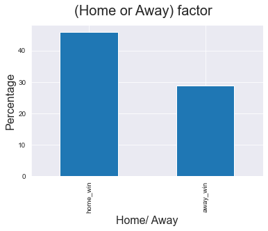

```python
(df_match.groupby(['match_result']).count()['id']/len(df_match)*100).nlargest(2).plot(kind='bar')
plt.suptitle('(Home or Away) factor', fontsize=20)
plt.xlabel('Home/ Away', fontsize=16)
plt.ylabel('Percentage', fontsize=16);
```

```python
# Determine exact values of probabilities
[prior_home, prior_away] = (df_match.groupby(['match_result']).count()['id']/len(df_match)*100).nlargest(2)
print('Home win probability equals {}%'.format(int(prior_home*10)/10))
print('Away win probability equals {}%'.format(int(prior_away*10)/10))
```

```
Home win probability equals 45.8%
Away win probability equals 28.8%
```

The previous chart gives us prior probabilities for the match result based on the first classification "Home or Away factor". These prior probabilities are **45.8%**, **28.8%**, and **25.4%** for home winning, away winning, and draw, respectively. The following factors are analyzed to show their effect on the match result "precisely, on the prior probabilities". This effect is represented numerically by calculating the posterior probabilities based on conditional probability and Bayes' Theroem.

#### b. Team lineup player's positions

Let's take the average (avg) Y coordinates of the player's positions to indicate attacking or defensive strategy. But, of the X direction, let's take the standard deviation (std) of the X coordinates to indicate wide or narrow strategy. Note that: average value of X coordinates is useless because in most cases lineups are symmetric between right and left of the court.

```python
# Add new columns with std values of x and average (avg) y coordinates of the lineup
start = df_match.columns.get_loc('home_player_X1') # get the first column index
columns = np.arange(start, start + 11)
df_match['home_player_X_std'] = df_match[df_match.columns[columns]].std(axis=1)
columns = np.arange(start + 11, start + 22)
df_match['away_player_X_std'] = df_match[df_match.columns[columns]].std(axis=1)
columns = np.arange(start + 22, start + 33)
df_match['home_player_Y_avg'] = df_match[df_match.columns[columns]].mean(axis=1)
columns = np.arange(start + 33, start + 44)
df_match['away_player_Y_avg'] = df_match[df_match.columns[columns]].mean(axis=1)
```

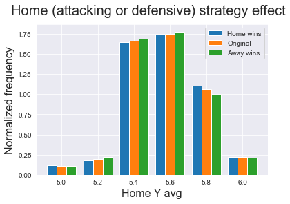

```python
original = df_match['home_player_Y_avg'].values
home = df_match.groupby(['match_result']).get_group('home_win')['home_player_Y_avg'].values
away = df_match.groupby(['match_result']).get_group('away_win')['home_player_Y_avg'].values
plt.hist([home, original, away], density=True, label=['Home wins', 'Original', 'Away wins'], bins=6, range=(4.9,6.1))
plt.legend()
plt.suptitle('Home (attacking or defensive) strategy effect', fontsize=20)
plt.xlabel('Home Y avg', fontsize=16)
plt.ylabel('Normalized frequency', fontsize=16);
```

This chart gives the original distribution (middle bars) of this factor compared with updated distributions based on the first classification (Home or Away factor) where home winning distribtions is on the left and away winning distribution is on the right. If this factor has no influence on the match result, it should gives three identical distributions. But, here the distributions are not identical which means this factor has an effect on the match result.

Example: the fifth category with Home Y avg value of 5.8 has three bars of different sizes. This means the probability of home winning is **increased** while the probability of away winning is **decrased** if the home team tends to lineup with more attacking strategy (Home Y avg value of 5.8).

To get a numerical meaning of **increased** and **decreased**, conditional probability is used in the following function.

```python
def posterior_probabilities(original, home, away, bins, hist_range):
    '''
    Arguments:
     original, home, away are three numerical arrays of the same size.
     bins is the number of bins requried in historgram as integer.
     hist_range contains two limit values in an ascending order as tuple.
    Usage: calculates the distributions of the three arrays based on the entered values of bin and hist_range,
     then calculates the posterior probabilities based on these distributions.
    Output: one graph to show the posterior probabilites of home winning and away winning compared with the prior probabilities.
    '''
    # Calculate original distribution
    heights_original = np.histogram(original, bins=bins, range=hist_range, density=True)[0]
    # Determine general graph parameters
    width = 0.25
    max_height = 100
    plt.figure()
    plt.axes(ylim=(0,max_height))
    # Draw prior probabilities
    plt.axhline(prior_home, color='b')
    plt.axhline(prior_away, color='r')
    # Determine graph parameters of Home wins
    heights_home = (np.histogram(home, bins=bins, range=hist_range, density=True)[0])/heights_original*prior_home
    locations_home = np.arange(1, len(heights_home)+1)
    home_win = plt.bar(locations_home, heights_home, width, color='b', label='Home wins')
    # Determine graph parameters of Away wins
    heights_away = (np.histogram(away, bins=bins, range=hist_range, density=True)[0])/heights_original*prior_away
    locations_away = locations_home + width
    away_win = plt.bar(locations_away, heights_away, width, color='r', label='Away wins')
    # Determine general graph parameters
    locations = locations_home + width/2
    labels_step = (hist_range[1]-hist_range[0])*10/bins
    labels_start = hist_range[0]*10 + labels_step/2
    labels_end = hist_range[1]*10 + labels_step/2
    labels = np.arange(labels_start, labels_end, labels_step)/10
    plt.xticks(locations, labels)
    plt.legend(loc='best')
```

Let's use the pervious function to analyze the same factor for home and away teams.

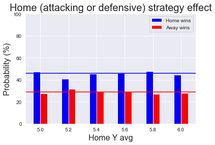

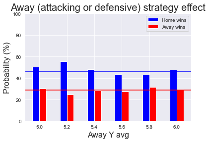

```python
# Generate home graph
original = df_match['home_player_Y_avg'].values
home = df_match.groupby(['match_result']).get_group('home_win')['home_player_Y_avg'].values
away = df_match.groupby(['match_result']).get_group('away_win')['home_player_Y_avg'].values
posterior_probabilities(original, home, away, bins=6, hist_range=(4.9,6.1))
plt.title('Home (attacking or defensive) strategy effect', fontsize=20)
plt.xlabel('Home Y avg', fontsize=16)
plt.ylabel('Probability (%)', fontsize=16)
# Generate away graph
origianl = df_match['away_player_Y_avg'].values
home = df_match.groupby(['match_result']).get_group('home_win')['away_player_Y_avg'].values
away = df_match.groupby(['match_result']).get_group('away_win')['away_player_Y_avg'].values
posterior_probabilities(original, home, away, bins=6, hist_range=(4.9,6.1))
plt.title('Away (attacking or defensive) strategy effect', fontsize=20)
plt.xlabel('Away Y avg', fontsize=16)
plt.ylabel('Probability (%)', fontsize=16);
```

The Home graph gives the same result of the previous histogram from the previous two cells, but here it's numerical representation. The horizontal lines (blue and red) represent the priror probabilities of home winning and away winning, respectively. If the factor has no influence on the match result, the bars should stop at the same height of the prior probabilities. But here, the bars are slightly increased and decreased which means it has an effect on the match result with posteriror probabilties which are represented by the heights of the bars.

Example: the fifth category with Home Y avg value of 5.8 has posterior porbabilities different than prior probabilities. This means the probability of home winning is **increased** (because it passes the blue horizontal line) while the probability of away winning is **decrased** (because it is below the red horizontal line) if the home team tends to lineup with more attacking strategy (Home Y avg value of 5.8).

Another example: The fourth category with Home Y avg value of 5.6 has almost no difference between the posterior and prior probabilities which means this factor has **no influnce** on the match result if the home team tends to lineup with moderate attacking strategy (Home Y avg value of 5.6)

Final example: The sixth category with Home Y avg value of 6 has posterior porbabilities different than prior probabilities, but this time, both the home winning and away winning probabilities are **decreased**, which means the third possibility of match result "Draw" has an **increase** in its probabilities.

This was an extensive analysis of the home graph to express the meaning of this graph. Other factors will be analyzed using the same way but in brief.

As a whole analysis for the home graph, it shows minor changes in probabilties except for the second category with middle class value of 5.2 as the home winning percentage decreased to **about 41%** and away winning percentage increased to **about 31%**. The away graph gives posterior probabilties different than prior probabilties due to the change in Away team attacking or defensive strategy. This difference is obvious at the category with middle class value of 5.2 where the home winning percentage reached more than **55%** while the away winning percentage decreased to about **24%**.

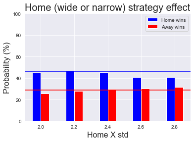

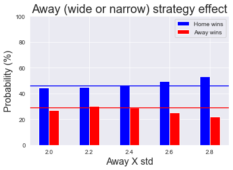

```python
# Generate home graph
original = df_match['home_player_X_std'].values
home = df_match.groupby(['match_result']).get_group('home_win')['home_player_X_std'].values
away = df_match.groupby(['match_result']).get_group('away_win')['home_player_X_std'].values
posterior_probabilities(original, home, away, bins=5, hist_range=(1.9,2.9))
plt.title('Home (wide or narrow) strategy effect', fontsize=20)
plt.xlabel('Home X std', fontsize=16)
plt.ylabel('Probability (%)', fontsize=16)
# Generate away graph
original = df_match['away_player_X_std'].values
home = df_match.groupby(['match_result']).get_group('home_win')['away_player_X_std'].values
away = df_match.groupby(['match_result']).get_group('away_win')['away_player_X_std'].values
posterior_probabilities(original, home, away, bins=5, hist_range=(1.9,2.9))
plt.title('Away (wide or narrow) strategy effect', fontsize=20)
plt.xlabel('Away X std', fontsize=16)
plt.ylabel('Probability (%)', fontsize=16);
```

The home wide or narrow strategy has almost not effect on prior probabilties with small change in proabilties in the categoris with values of 2.6 and 2.8 which means, more wide strategy of home team decreases the probabilities of home winning. The same result comes from the away graph where more wide strategy of away team decreases the probabilities of away winning.

#### c. Average players' age

```python
# extract match year from date column
df_match['match_year'] = df_match['date'].dt.year
# extract player's year of birth from birthdate
df_player['birthyear'] = df_player['birthday'].dt.year
```

From now on, a new dataframe will be used instead of modifing the original one.

```python
# Create new dataframe
df_match_age = df_match.copy()
# Add players' birthyears to match table
start = df_match_age.columns.get_loc('home_player_1') # get the first player column index
for i in range(start, start + 22):
    df_match_age[df_match_age.columns[i] + '_age'] = (df_match_age['match_year'] -
                                                      df_match_age[df_match_age.columns[i]].map(df_player.set_index('player_api_id')['birthyear']))
# Clean the dataframe if mapping returns nan
df_match_age.dropna(inplace=True)
# Get average home_player_age
start = df_match_age.columns.get_loc('home_player_1_age') # get the first age column index
columns = np.arange(start, start + 11) # set columns' indecies
df_match_age['home_player_age'] = df_match_age[df_match_age.columns[columns]].mean(axis=1)
# Get average away_player_age
columns = np.arange(start + 11, start + 22) # set columns' indecies
df_match_age['away_player_age'] = df_match_age[df_match_age.columns[columns]].mean(axis=1)
```

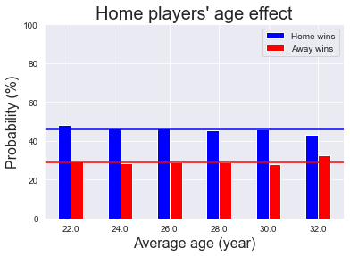

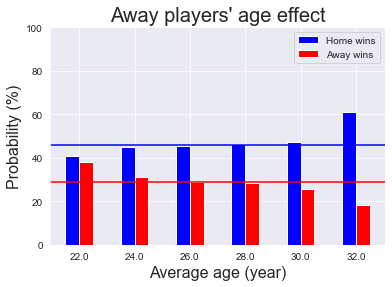

```python
# Generate home graph
original = df_match_age['home_player_age'].values
home = df_match_age.groupby(['match_result']).get_group('home_win')['home_player_age'].values
away = df_match_age.groupby(['match_result']).get_group('away_win')['home_player_age'].values
posterior_probabilities(original, home, away, bins=6, hist_range=(21,33))
plt.title('Home players\' age effect', fontsize=20)
plt.xlabel('Average age (year)', fontsize=16)
plt.ylabel('Probability (%)', fontsize=16)
# Generate away graph
original = df_match_age['away_player_age'].values
home = df_match_age.groupby(['match_result']).get_group('home_win')['away_player_age'].values
away = df_match_age.groupby(['match_result']).get_group('away_win')['away_player_age'].values
posterior_probabilities(original, home, away, bins=6, hist_range=(21,33))
plt.title('Away players\' age effect', fontsize=20)
plt.xlabel('Average age (year)', fontsize=16)
plt.ylabel('Probability (%)', fontsize=16);
```

The home player's average age barely affect the prior probabilities as it has minor effects on the exteme categories only. The away player's average age has the same effect but with major effect on the extreme categories as the winning percentage of home team reached more **60%** when away player's average age lies in the category with middle class value of 32.

#### d. Players' attributes

The player attributes table contains the history of each player's attribute, but the updates are not consistent for each player as illustrated in the data wrangling step. Some players have +10 updates and others have only two. So, for the analysis of player's attribute effect on match result, the average value of the palyer's attribute will be taken.

The following cell contains a general function to show the effect of any player's attribute with numeical values on the match result. After then, there is another function to show the effect of attributes with string values.

```python
def player_attribute_numeric(attribute='overall_rating'):
    '''
    Argument: attribute as string (it should be one of the player's attribute with numerical values)
    Usage: adds the values of this attribute to the new dataframe
    Output: a dataframe
    '''
    # Check if the entered attribute is in the player attributes table
    if attribute not in df_player_attributes.columns:
        print('Sorry, this attribute is not in the player attributes table!')
        return pd.DataFrame({'a' : []})
    # Check if the entered attribute has numerical values
    elif not pd.api.types.is_numeric_dtype(df_player_attributes[attribute]):
        print('Sorry, this attribute has no numerical values!\nPlease use the function "player_attribute_str" instead.')
        return pd.DataFrame({'a' : []})
    # Make a copy of the match dataframe
    df = df_match.copy()
    # Make a copy of the player dataframe after adding the average value of this attribute to it
    df_attribute = pd.concat([df_player.set_index('player_api_id'),
                                          df_player_attributes.groupby(['player_api_id']).mean()[attribute]], axis=1)
    # Clean the dataframe if concatination returns nan
    df_attribute.dropna(axis=0, inplace=True)
    # Add the players' attribute average value to the matches table
    start = df.columns.get_loc('home_player_1') # get the first player column index
    for i in range(start, start + 22):
        df[df.columns[i] + '_{}'.format(attribute)] = df[df.columns[i]].map(df_attribute[attribute])
    # Clean the dataframe if mapping returns nan
    df.dropna(axis=0, inplace=True)
    # Get average home_player_attribute value
    start = df.columns.get_loc('home_player_1_{}'.format(attribute)) # get the first attribute column index
    columns = np.arange(start, start + 11) # set columns' indecies
    df['home_player_{}'.format(attribute)] = df[df.columns[columns]].mean(axis=1)
    # Get average away_player_attribute value
    columns = np.arange(start + 11, start + 22) # set columns' indecies
    df['away_player_{}'.format(attribute)] = df[df.columns[columns]].mean(axis=1)
    return df
```

Let's start by looking at the overall rating attribute

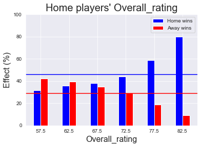

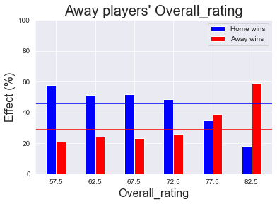

```python
attribute = 'overall_rating'
df = player_attribute_numeric(attribute)
if not df.empty:
    # Generate home graph
    original = df['home_player_{}'.format(attribute)].values
    home = df.groupby(['match_result']).get_group('home_win')['home_player_{}'.format(attribute)].values
    away = df.groupby(['match_result']).get_group('away_win')['home_player_{}'.format(attribute)].values
    posterior_probabilities(original, home, away, bins=6, hist_range=(55,85))
    plt.title('Home players\' {}'.format(attribute.capitalize()), fontsize=20)
    plt.xlabel(attribute.capitalize(), fontsize=16)
    plt.ylabel('Effect (%)', fontsize=16)
    # Generate away graph
    original = df['away_player_{}'.format(attribute)].values
    home = df.groupby(['match_result']).get_group('home_win')['away_player_{}'.format(attribute)].values
    away = df.groupby(['match_result']).get_group('away_win')['away_player_{}'.format(attribute)].values
    posterior_probabilities(original, home, away, bins=6, hist_range=(55,85))
    plt.title('Away players\' {}'.format(attribute.capitalize()), fontsize=20)
    plt.xlabel(attribute.capitalize(), fontsize=16)
    plt.ylabel('Effect (%)', fontsize=16);
```

The two graphs give logical results as they indicate a great effect of the overall_rating attribute on the probabilities. The less the values of home players'overall rating the less the probability of home winning, it even decreases than the away winning probability. And the more the values of home players'overall rating the more the probability of home winning, it even reaches **80%**! at the last category (from 80 to 85). The same result comes from the analysis of the away graph with great increase in the away winning probability **(about 59%)**! at the last category (from 80 to 85).

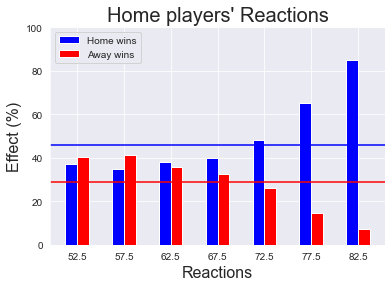

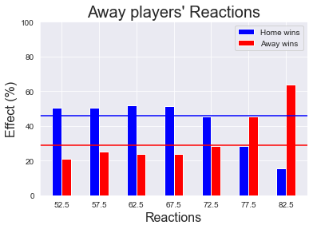

```python
attribute = 'reactions'
df = player_attribute_numeric(attribute)
if not df.empty:
    # Generate home graph
    original = df['home_player_{}'.format(attribute)].values
    home = df.groupby(['match_result']).get_group('home_win')['home_player_{}'.format(attribute)].values
    away = df.groupby(['match_result']).get_group('away_win')['home_player_{}'.format(attribute)].values
    posterior_probabilities(original, home, away, bins=7, hist_range=(50,85))
    plt.title('Home players\' {}'.format(attribute.capitalize()), fontsize=20)
    plt.xlabel(attribute.capitalize(), fontsize=16)
    plt.ylabel('Effect (%)', fontsize=16)
    # Generate away graph
    original = df['away_player_{}'.format(attribute)].values
    home = df.groupby(['match_result']).get_group('home_win')['away_player_{}'.format(attribute)].values
    away = df.groupby(['match_result']).get_group('away_win')['away_player_{}'.format(attribute)].values
    posterior_probabilities(original, home, away, bins=7, hist_range=(50,85))
    plt.title('Away players\' {}'.format(attribute.capitalize()), fontsize=20)
    plt.xlabel(attribute.capitalize(), fontsize=16)
    plt.ylabel('Effect (%)', fontsize=16);
```

The previous pattern holds true for the reactions attribute. Here, the home winning probability reaches **more than 80%**! when home players' reactions are between 80 and 85, and the away winning probability reaches **more than 60%**! when away player's reactions are between 80 and 85.

All other numerical attributes can be analyzed the same way. **Please, feel free to change the attribute value in the next cell, then run it.**

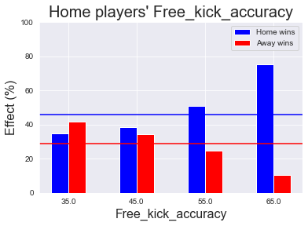

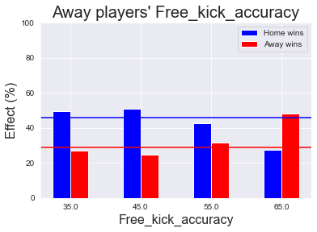

```python
# Change the value of the attribute variable with appropriate attribute name then run the cell
attribute = 'free_kick_accuracy'
df = player_attribute_numeric(attribute)
if not df.empty:
    # Generate home graph
    original = df['home_player_{}'.format(attribute)].values
    home = df.groupby(['match_result']).get_group('home_win')['home_player_{}'.format(attribute)].values
    away = df.groupby(['match_result']).get_group('away_win')['home_player_{}'.format(attribute)].values
    posterior_probabilities(original, home, away, bins=4, hist_range=(30,70))
    plt.title('Home players\' {}'.format(attribute.capitalize()), fontsize=20)
    plt.xlabel(attribute.capitalize(), fontsize=16)
    plt.ylabel('Effect (%)', fontsize=16)
    # Generate away graph
    original = df['away_player_{}'.format(attribute)].values
    home = df.groupby(['match_result']).get_group('home_win')['away_player_{}'.format(attribute)].values
    away = df.groupby(['match_result']).get_group('away_win')['away_player_{}'.format(attribute)].values
    posterior_probabilities(original, home, away, bins=4, hist_range=(30,70))
    plt.title('Away players\' {}'.format(attribute.capitalize()), fontsize=20)
    plt.xlabel(attribute.capitalize(), fontsize=16)
    plt.ylabel('Effect (%)', fontsize=16);
```

The following function is to do the same analysis on attributes with string values.

```python
def player_attribute_str(attribute='attacking_work_rate'):
    '''
    Argument: attribute as string (it should be one of the player's attribute with string values)
    Usage: adds the values of this attribute to the new dataframe then gives two graphs to show the effect of this
    attribute on match result
    Output: Two graphs (One for home players and the other for away players)
    '''
    # Check if the entered attribute is in the player attributes table
    if attribute not in df_player_attributes.columns:
        print('Sorry, this attribute is not in the player attributes table!')
        return
    # Check if the entered attribute has string values
    elif not pd.api.types.is_string_dtype(df_player_attributes[attribute]):
        print('Sorry, this attribute has no string values!\nPlease use the function "player_attribute_numeric instead".')
        return
    # Make a copy of the match dataframe
    df = df_match.copy()
    # Make a copy of the player dataframe after adding the mode of this attribute to it
    df_attribute = pd.concat([df_player.set_index('player_api_id'),
                              df_player_attributes.groupby(['player_api_id'])[attribute].agg(lambda x: pd.Series.mode(x)[0])], axis=1)
    # Clean the dataframe if concatination returns nan
    df_attribute.dropna(inplace=True)
    # Add the players' attribute mode value to the matches table
    start = df.columns.get_loc('home_player_1') # get the first player column index
    for i in range(start, start + 22):
        df[df.columns[i] + '_{}'.format(attribute)] = df[df.columns[i]].map(df_attribute[attribute])
    # Clean the dataframe if mapping returns nan
    df.dropna(inplace=True)
    # Get mode of home_player_attribute
    start = df.columns.get_loc('home_player_1_{}'.format(attribute)) # get the first attribute column index
    columns = np.arange(start, start + 11) # set columns' indecies
    df['home_player_{}'.format(attribute)] = df[df.columns[columns]].astype('str').mode(axis=1)[0]
    # Get mode of away_player_attribute
    columns = np.arange(start + 11, start + 22) # set columns' indecies
    df['away_player_{}'.format(attribute)] = df[df.columns[columns]].astype('str').mode(axis=1)[0]

    # Generate home graph
    width = 0.25
    max_height = 100
    plt.figure(1)
    plt.axes(ylim=(0,max_height))
    # Draw prior probabilities
    plt.axhline(prior_home, color='b')
    plt.axhline(prior_away, color='r')
    # Calculate Original distribution
    heights_original = df['home_player_{}'.format(attribute)].value_counts(normalize=True)
    locations_original = np.arange(1, len(heights_original)+1) + width
    # Determine heights and locations of Home and away
    heights_home = df.groupby(['match_result']).get_group('home_win')['home_player_{}'.format(attribute)].value_counts(normalize=True)/heights_original*prior_home
    locations_home = locations_original - width/2
    heights_away = df.groupby(['match_result']).get_group('away_win')['home_player_{}'.format(attribute)].value_counts(normalize=True)/heights_original*prior_away
    locations_away = locations_original + width/2
    heights = pd.concat([heights_original, heights_home, heights_away], axis=1).set_axis(['original', 'home', 'away'], axis=1)
    home_win = plt.bar(locations_home, heights['home'], width, color='b', label='Home wins')
    away_win = plt.bar(locations_away, heights['away'], width, color='r', label='Away wins')
    # Determine general graph parameters
    labels = df['home_player_{}'.format(attribute)].value_counts(normalize=True).index
    plt.xticks(locations_original, labels)
    plt.title('Home players\' {} effect'.format(attribute.capitalize()), fontsize=20)
    plt.xlabel(attribute.capitalize(), fontsize=16)
    plt.ylabel('Probability (%)', fontsize=16)
    plt.legend(loc='best');

    # Generate away graph
    width = 0.25
    max_height = 100
    plt.figure(2)
    plt.axes(ylim=(0,max_height))
    # Draw prior probabilities
    plt.axhline(prior_home, color='b')
    plt.axhline(prior_away, color='r')
    # Determine graph parameters of Original
    heights_original = df['away_player_{}'.format(attribute)].value_counts(normalize=True)
    locations_original = np.arange(1, len(heights_original)+1)
    # Determine heights and locations of Home and away
    heights_home = df.groupby(['match_result']).get_group('home_win')['away_player_{}'.format(attribute)].value_counts(normalize=True)/heights_original*prior_home
    locations_home = locations_original - width/2
    heights_away = df.groupby(['match_result']).get_group('away_win')['away_player_{}'.format(attribute)].value_counts(normalize=True)/heights_original*prior_away
    locations_away = locations_original + width/2
    heights = pd.concat([heights_original, heights_home, heights_away], axis=1).set_axis(['original', 'home', 'away'], axis=1)
    home_win = plt.bar(locations_home, heights['home'], width, color='b', label='Home wins')
    away_win = plt.bar(locations_away, heights['away'], width, color='r', label='Away wins')
    # Determine general graph parameters
    labels = df['away_player_{}'.format(attribute)].value_counts().index
    plt.xticks(locations_original, labels)
    plt.title('Away players\' {} effect'.format(attribute.capitalize()), fontsize=20)
    plt.xlabel(attribute.capitalize(), fontsize=16)
    plt.ylabel('Probability (%)', fontsize=16)
    plt.legend(loc='best');
```

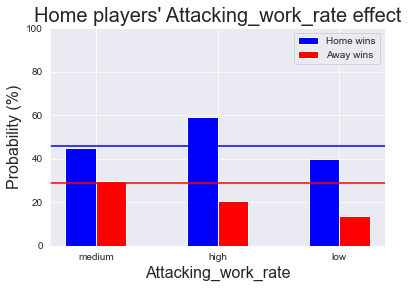

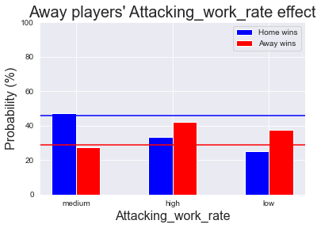

```python
attribute = 'attacking_work_rate'
player_attribute_str(attribute)
```

The players' attacking work rate factor influences the prior probabilties for the low and high categories in both graphs. It's logical that medium class has no great effect because its the average (mode) value. When the home players' attacking work rate is high, there is more chance of home winning. The same result holds true for the away players.

An intersting note that when the home players' attacking work rate is low, both home and away winning probabilities are decreased which means the draw probability increases! But this result is not the same for the away players where the probability of away winning increaes when the away players' attacking work rate is low! This might be strange but it seems logical by consedring this is an away match for the players.

All other string attributes can be analyzed the same way. **Please, feel free to change the attribute value in the next cell.**

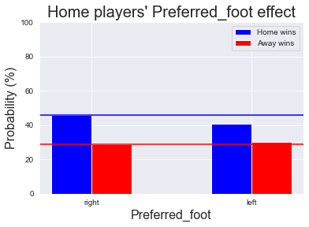

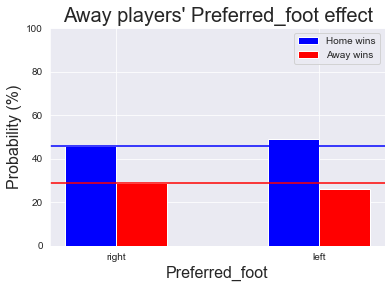

```python
# Change the value of this variable with appropriate attribute name then run the cell
attribute = 'preferred_foot'
player_attribute_str(attribute)
```

#### e. Teams' attributes

The same procedure will be followed for these factors. One function for the attributes with numerical values and another one for the attribtues with string values.

```python
def team_attribute_numeric(attribute='buildUpPlaySpeed'):
    '''
    Argument: attribute as string (it should be one of the team's attribute with numerical values)
    Usage: adds the values of this attribute to the new dataframe
    Output: a dataframe
    '''
    # Check if the entered attribute is in the team attributes table
    if attribute not in df_team_attributes.columns:
        print('Sorry, this attribute is not in the team attributes table!')
        return pd.DataFrame({'a' : []})
    # Check if the entered attribute has numerical values
    elif not pd.api.types.is_numeric_dtype(df_team_attributes[attribute]):
        print('Sorry, this attribute has no numerical values!\nPlease use the function "team_attribute_str" instead.')
        return pd.DataFrame({'a' : []})
    # Make a copy of the match dataframe
    df = df_match.copy()
    # Make a copy of the team dataframe after adding the average value of this attribute to it
    df_attribute = pd.concat([df_team.set_index('team_api_id'),
                                          df_team_attributes.groupby(['team_api_id']).mean()[attribute]], axis=1)
    # Clean the dataframe if concatination returns nan
    df_attribute.dropna(axis=0, inplace=True)
    # Map the teams' attribute to the matches table
    df['home_team_{}'.format(attribute)] = df['home_team_api_id'].map(df_attribute[attribute])
    df['away_team_{}'.format(attribute)] = df['away_team_api_id'].map(df_attribute[attribute])
    # Clean the dataframe if mapping returns nan
    df.dropna(axis=0, inplace=True)
    return df
```

There is no attribute with overall rating for the teams like the players, so let's start by any attribute.

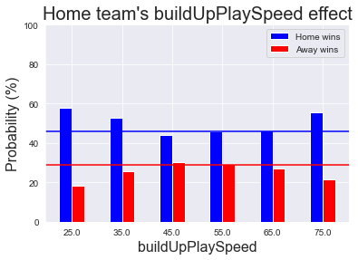

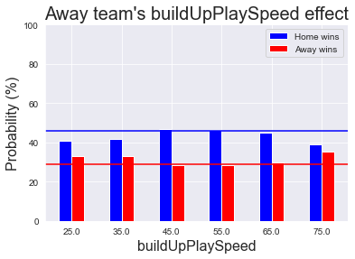

```python
attribute = 'buildUpPlaySpeed'
df = team_attribute_numeric(attribute)
if not df.empty:
   # Generate home graph
    original = df['home_team_{}'.format(attribute)].values
    home = df.groupby(['match_result']).get_group('home_win')['home_team_{}'.format(attribute)].values
    away = df.groupby(['match_result']).get_group('away_win')['home_team_{}'.format(attribute)].values
    posterior_probabilities(original ,home, away, bins=6, hist_range=(20,80))
    plt.title('Home team\'s {} effect'.format(attribute), fontsize=20)
    plt.xlabel(attribute, fontsize=16)
    plt.ylabel('Probability (%)', fontsize=16)
    # Generate away graph
    original = df['away_team_{}'.format(attribute)].values
    home = df.groupby(['match_result']).get_group('home_win')['away_team_{}'.format(attribute)].values
    away = df.groupby(['match_result']).get_group('away_win')['away_team_{}'.format(attribute)].values
    posterior_probabilities(original ,home, away, bins=6, hist_range=(20,80))
    plt.title('Away team\'s {} effect'.format(attribute), fontsize=20)
    plt.xlabel(attribute, fontsize=16)
    plt.ylabel('Probability (%)', fontsize=16);
```

The team's build up play speed attribute has minor effects on the prior probabilities where the effect appears only on the exterme categories. Less home speeds or more home speed than average increases the probability of home winning with the same effect of away speeds on the away winning probabilities.

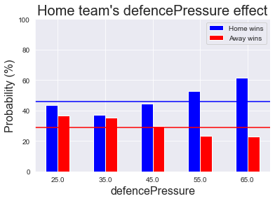

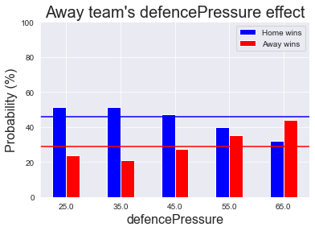

```python
attribute = 'defencePressure'
df = team_attribute_numeric(attribute)
if not df.empty:
   # Generate home graph
    original = df['home_team_{}'.format(attribute)].values
    home = df.groupby(['match_result']).get_group('home_win')['home_team_{}'.format(attribute)].values
    away = df.groupby(['match_result']).get_group('away_win')['home_team_{}'.format(attribute)].values
    posterior_probabilities(original ,home, away, bins=5, hist_range=(20,70))
    plt.title('Home team\'s {} effect'.format(attribute), fontsize=20)
    plt.xlabel(attribute, fontsize=16)
    plt.ylabel('Probability (%)', fontsize=16)
    # Generate away graph
    original = df['away_team_{}'.format(attribute)].values
    home = df.groupby(['match_result']).get_group('home_win')['away_team_{}'.format(attribute)].values
    away = df.groupby(['match_result']).get_group('away_win')['away_team_{}'.format(attribute)].values
    posterior_probabilities(original ,home, away, bins=5, hist_range=(20,70))
    plt.title('Away team\'s {} effect'.format(attribute), fontsize=20)
    plt.xlabel(attribute, fontsize=16)
    plt.ylabel('Probability (%)', fontsize=16);
```